# Topic extraction with side information for sustainability analysis

## Motivation

- Growing interest to sustainable investments
- Investment decisions integrate individual value systems
- Aligning investments with individual preferences
  - how to quantify sustainability?
  - how to compare investment possibilities?
- Environment, social, governance (ESG) ratings diverge as Berg, Kölbel, and Rigobon (2022) in “Aggregated confusion The Divergence of ESG Ratings”

## Motivation

- Kang and Kim (2022): Another source of information easily available to private investors
  - corporate responsibility reports
  - sustainability reports
  - environmental action reports
- A systematics e.g. in commonly accepted 17 UN sustainable development goals (SDGs) is at hand.

[figure not shown]

→ leverage information from these sources via automatic topic extraction while considering the value system established by the 17 SDGs.

## Methods available

- Topic analysis: represent each document/ context in a low dimensional latent topic space:
  - Specific for topic extraction: Latent (probabilistic) Semantic Analysis, Latent Dirichlet allocation (LDA) and extentions thereof.
  - General purpose matrix factorization (MF) methods: Principal component analysis, Non-negativ matrix factorization, probabilistic versions and extensions thereof.

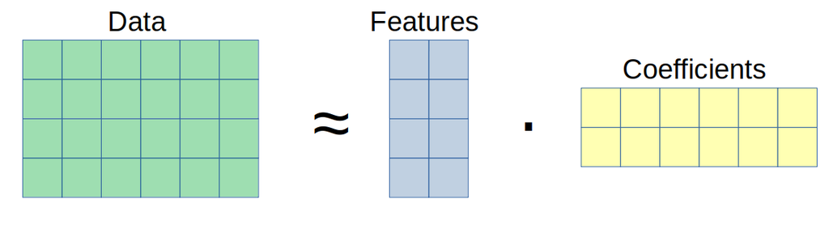

- How to embed known structure or side information in the unsupervised techniques?
  - keyword seeded LDA: Watanabe and Zhou (2022) and Eshima, Imai, and Sasaki (2023)
  - graph regularized MF: Rao et al. (2015) and Zhang et al. (2020) (recommendations)
  - common subspace projection/ subspace alignment (Fernando et al. (2013) for domain adaptation)
  - matrix co-factorization (MCF) techniques: Fang and Si (2011) (user communities) and Luo et al. (2019) (recommender systems)

→ adopt MCF for topic extraction with side information.

## Our approach

Decompose two term-context matrices (*M* from the sustainability reports and *C* from the SDG texts) jointly.

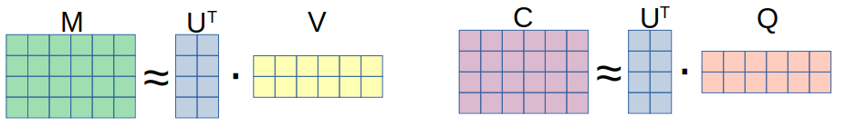

- *M* is the (weighted) term-context matrix for the corporate reports with dimensions (*p*×*n*), where *p* is the joint vocabulary.
- *C* is the (weighted) term-context matrix for the sustainability goals with dimensions (*p*×*m*), where *p* is again the joint vocabulary.
- *U* is the term-topic representation matrix of dimensions (*p*×*k*), where *k* is the number of topics.
- *V*/*Q* is the context-topic representation matrix for the reports/SGDs of dimensions (*k*×*n*).

The associated MCF problem is then:

min (||*M*−*U*<sup>⊤</sup>*V*||<sup>2</sup>+*λ*||*C*−*U*<sup>⊤</sup>*Q*||<sup>2</sup>)

where *λ* adapts the importance of the loss on the second factorization term.

To preserve the non-negativity of the entries in *M* and *C*, to inhance interpretability → restrict the components to be non-negative:

s.t. *U*,*V*,*Q*≥0 elementwise.

## The algorithm

- alternating minimization/ alternating projection
- hierarchical non-negative alternating least squares (HALS) of Cichocki, Zdunek, and Amari (2007)
- with a modification for the co-factorization setup

*X*<sub>*k*</sub> denotes the *k*th row of the matrix *X* and *X*<sub>−*k*</sub> denotes the matrix without its *k*th row.

## Optimal *K* and *λ*

- find the optimal *k* and *λ* in a data-driven fashion, via maximizing the **mean coherence**
- mean coherence $\overline{coh}$: the mean of the logratio topic coherence: log (*ϵ*+*T**C**M*<sub>*x*, *y*</sub>) − log (*T**C**M*<sub>*y*, *y*</sub>) for two terms *x*, *y* with *T**C**M* being the in-sample term co-occurrence matrix.
- for *K* = 8, *λ* = 0: $coh\_{sustainability\\\_reports} =-1.3048, coh\_{SDGs}= -7.7671 , \overline{coh} = {\color{red}{-4.5359}}$
- for *K* = 8, *λ* = 350: $coh\_{sustainability\\\_reports} =-2.6230, coh\_{SDGs}= -0.9374 , \overline{coh} = {\color{teal}{ -1.7802}}$

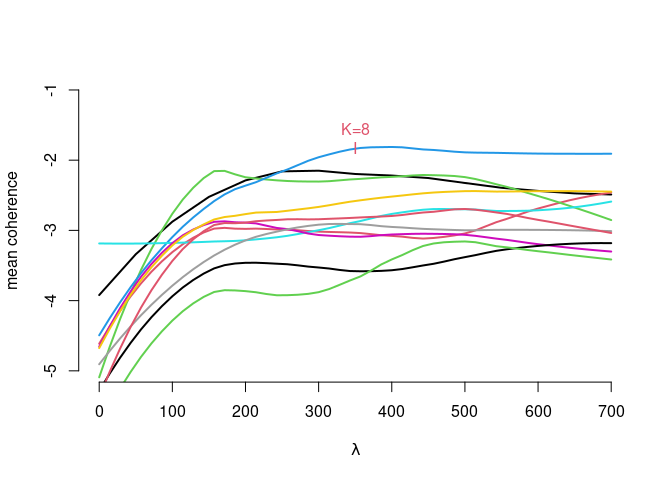

## Results: the topics

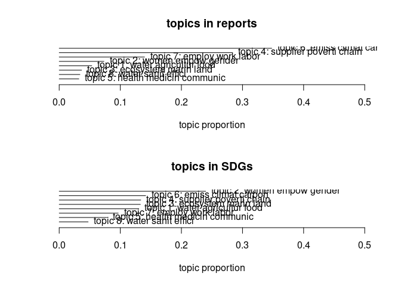

[figure not shown]

## Results: approximation in two dimensions

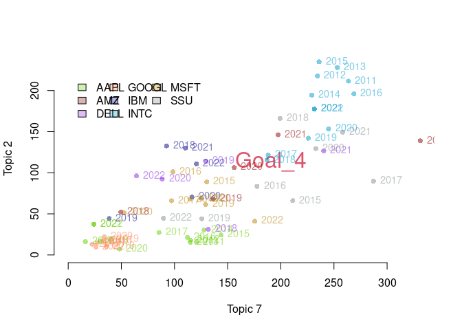

## Results: the distributional distances

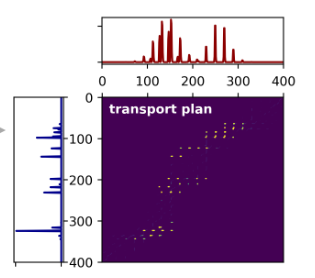

(Source: http://alexhwilliams.info/itsneuronalblog/2020/10/09/optimal-transport/#f5b )

Lee et al. (2022) cosine dissimilarity as cost for optimal transport plan (contextualized mover’s distance,CMD):
$$Cost\_{ij}^{CMD}=1-\frac{x\_i^\top
x\_j}{||x\_i||||x\_j||}$$

with *x*<sub>*k*</sub>, *k* = 1, …, *n* being the topic-term embedding for the *k*th term.

## Results: distributional distances

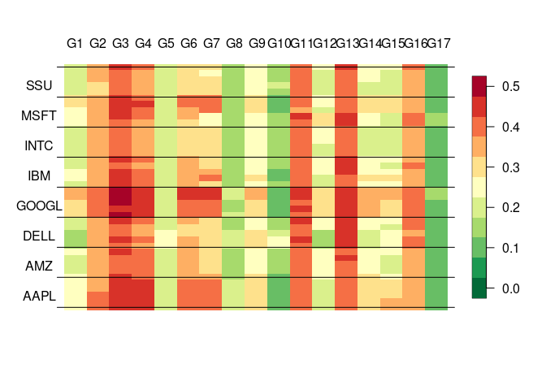

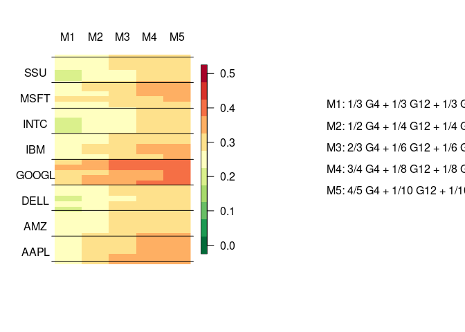

## Summary

- Topic extraction with side information → low dim. representation in a prestructured topic space.
- Projection on a common subspace via non-negative matrix co-factorization, using an algorithm which is easily implemented and delivers interpretable results.
- The resulting topic-term embeddings are used to compare the documents via the optimal transport metric which assists financial decisions under SDGs based preferences.

## References

Berg, Florian, Julian F Kölbel, and Roberto Rigobon. 2022. “Aggregate Confusion: The Divergence of ESG Ratings*.” *Review of Finance* 26 (6): 1315–44. https://doi.org/10.1093/rof/rfac033.

Cichocki, Andrzej, Rafal Zdunek, and Shun-ichi Amari. 2007. “Hierarchical ALS Algorithms for Nonnegative Matrix and 3D Tensor Factorization.” In *Independent Component Analysis and Signal Separation*, edited by Mike E. Davies, Christopher J. James, Samer A. Abdallah, and Mark D. Plumbley, 169–76. Berlin, Heidelberg: Springer Berlin Heidelberg.

Eshima, Shusei, Kosuke Imai, and Tomoya Sasaki. 2023. “Keyword Assisted Topic Models.” https://arxiv.org/abs/2004.05964.

Fang, Yi, and Luo Si. 2011. “Matrix Co-Factorization for Recommendation with Rich Side Information and Implicit Feedback.” In *Proceedings of the 2nd International Workshop on Information Heterogeneity and Fusion in Recommender Systems*, 65–69. HetRec ’11. New York, NY, USA: Association for Computing Machinery. https://doi.org/10.1145/2039320.2039330.

Fernando, Basura, Amaury Habrard, Marc Sebban, and Tinne Tuytelaars. 2013. “Unsupervised Visual Domain Adaptation Using Subspace Alignment.” In *2013 IEEE International Conference on Computer Vision*, 2960–67. https://doi.org/10.1109/ICCV.2013.368.

Kang, Hyewon, and Jinho Kim. 2022. “Analyzing and Visualizing Text Information in Corporate Sustainability Reports Using Natural Language Processing Methods.” *Applied Sciences* 12 (11). https://doi.org/10.3390/app12115614.

Lee, Seonghyeon, Dongha Lee, Seongbo Jang, and Hwanjo Yu. 2022. “Toward Interpretable Semantic Textual Similarity via Optimal Transport-Based Contrastive Sentence Learning.” In *Proceedings of the 60th Annual Meeting of the Association for Computational Linguistics (Volume 1: Long Papers)*, 5969–79. Dublin, Ireland: Association for Computational Linguistics. https://doi.org/10.18653/v1/2022.acl-long.412.

Luo, Ling, Haoran Xie, Yanghui Rao, and Fu Lee Wang. 2019. “Personalized Recommendation by Matrix Co-Factorization with Tags and Time Information.” *Expert Systems with Applications* 119: 311–21. https://doi.org/https://doi.org/10.1016/j.eswa.2018.11.003.

Rao, Nikhil, Hsiang-Fu Yu, Pradeep K Ravikumar, and Inderjit S Dhillon. 2015. “Collaborative Filtering with Graph Information: Consistency and Scalable Methods.” In *Advances in Neural Information Processing Systems*, edited by C. Cortes, N. Lawrence, D. Lee, M. Sugiyama, and R. Garnett. Vol. 28. Curran Associates, Inc. https://proceedings.neurips.cc/paper_files/paper/2015/file/f4573fc71c731d5c362f0d7860945b88-Paper.pdf.

Watanabe, Kohei, and Yuan Zhou. 2022. “Theory-Driven Analysis of Large Corpora: Semisupervised Topic Classification of the UN Speeches.” *Social Science Computer Review* 40 (2): 346–66. https://doi.org/10.1177/0894439320907027.

Zhang, Yupei, Yue Yun, Huan Dai, Jiaqi Cui, and Xuequn Shang. 2020. “Graphs Regularized Robust Matrix Factorization and Its Application on Student Grade Prediction.” *Applied Sciences* 10 (5). https://doi.org/10.3390/app10051755.

[1] Hochschule für Wirtschaft und Recht Berlin; osipenko@hwr-berlin.de